# 10-Monkey-Species Project -- Capstone project

# 1 .. Definition

## The aim of the project is to find the best algorithm which will classify the 10-monkey-species with good accurecy

Recognizing the animal in the wild is critical for understanding the evolutionary process that guide bio diversity.

Iilegal trade is the most important concern which is causing the reducing number of species globally. So we need to do fight against such illegal trade and trafficking.

So there is urgent need to identify the species using some non-intrusive way. So using computer vision techniques this seems to be promising and easy to implement.

Since the humans are also evolved from monkeys the technique used for human facial identification may work. SO CNNs are going to help us to identify the type of monkey species.

Once the model has been developed people can use it as a part of mobile app which can be used to identify the image.

Not all Humans are capable of identifying all the types of monkeys. ML with CNN helps to identify the type of species You can find similar related work in this link https://arxiv.org/pdf/1804.08790.pdf

## Problem Statement

Identifying the type of the moneky species from the given image. the type of the species we are classifying are

```
mantled_howler
patas_monkey
bald_uakari
japanese_macaque
pygmy_marmoset
white_headed_capuchin
silvery_marmoset
common_squirrel_monkey
black_headed_night_monkey
nilgiri_langur
```

So here we are trying solve the multiclass classification problem

Steps involved are preprocess the data define a CNN model use softmax function to classify image using 10 probablities (10 classes) the one which has high probablity is the type of species

## Metrics

Accuracy is important metric for the model in classifying the image. After model has been made how many test images the model correctly classified by number of test images

Accuracy = (total images correctly classified in test set )/(total images in test set)

Since the number of images are less. We will be using data augmentation. So this help in identifying the image in different locations in a frame

In Classification below metrics will help in understading if the model is good or not is

Classification Acuurecy : As difined above how many test images are getting classified correctly by model

Confusion Matrix : this matrix will give how many images are getting correctly classified and which are classified wrong.. false postives/false negitives

Log Loss / Cross entropy: works by penalizing false classificaton. useful for the multiclass classification problem. value near 0 is high accurecy .. near 1 is having low accurecy

For our model we will look at classification acucrecy and confusion matrix. we can use the algorithm which is having best score on acuurecy and confusion matrix

#### Dataset is downloaded from the https://www.kaggle.com/slothkong/10-monkey-species/

in this notebook we are going to work on the dataset of identifying the species type of monkey. we will be using CNN to identify the species type of monkey if the imput image is given

#### The plan to solve the issue

step 1: import all modules

step 2: import dataset (data augumentation )

step 3: create a simple CNN model to classify the image

step 4: FInding accurecy of CNN model created

step 5: use transfer learning

step 6: write a function using best algorithm

step 7: test and identify the algorithm

### import modules

```python
import matplotlib.pyplot as plt
import numpy as np
import pandas as pd
import tensorflow as tf
from tqdm import tqdm
from scipy import ndimage
from pathlib import Path
from sklearn.metrics import classification_report, confusion_matrix
from sklearn import metrics
import matplotlib.pyplot as plt

from PIL import Image
%matplotlib inline
```

# 2. Analysis

## Data Exploration

the data set can be downlaoded from the  
https://www.kaggle.com/slothkong/10-monkey-species

In classification technique when the data belonging to one class is very less compared to other class. With the imbalance in data the model can be more biased and inaccurate. The class which is having more data it will become overfit And less data class become underfit So to avoid this I will be using Imagegenator from keras which will take the traing dir (which contains sub dir per class)

Keras provides the ImageDataGenerator class that defines the configuration for image data preparation and augmentation. This includes capabilities such as:

```
Sample-wise standardization.
Feature-wise standardization.
ZCA whitening.
Random rotation, shifts, shear and flips.
Dimension reordering.
Save augmented images to disk.
```

Image genrator will return the sample of images when requested. we will use module with flow_from_dir which will take images from diffrent folder inside the given folder. each fodler represents one class used for training

### Importing Datasets

```python
train_dir = Path('./training/training/')
test_dir = Path('./validation/validation/')
#cols = ['Label','Latin Name', 'Common Name','Train Images', 'Validation Images']
labels = pd.read_csv("./monkey_labels.txt")
labels
```

|  | Label | Latin Name | Common Name | Train Images | Validation Images |
| --- | --- | --- | --- | --- | --- |
| 0 | n0 | alouatta_palliata\t | mantled_howler | 131 | 26 |
| 1 | n1 | erythrocebus_patas\t | patas_monkey | 139 | 28 |
| 2 | n2 | cacajao_calvus\t | bald_uakari | 137 | 27 |
| 3 | n3 | macaca_fuscata\t | japanese_macaque | 152 | 30 |
| 4 | n4 | cebuella_pygmea\t | pygmy_marmoset | 131 | 26 |
| 5 | n5 | cebus_capucinus\t | white_headed_capuchin | 141 | 28 |
| 6 | n6 | mico_argentatus\t | silvery_marmoset | 132 | 26 |
| 7 | n7 | saimiri_sciureus\t | common_squirrel_monkey | 142 | 28 |
| 8 | n8 | aotus_nigriceps\t | black_headed_night_monkey | 133 | 27 |
| 9 | n9 | trachypithecus_johnii | nilgiri_langur | 132 | 26 |

# Exploratory Visualization

lets look at the data of image..

The images are given in 3 dimensaions

```
  Red
  Green
  Blue
```

They are given in diffrent pixels... Lets look at data in detail

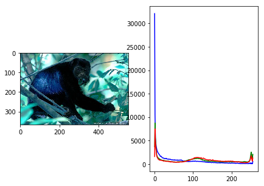

[figure not shown]

[figure not shown]

[figure not shown]

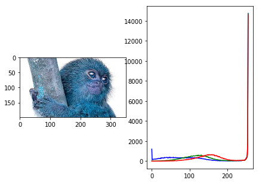

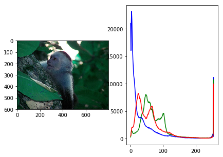

[figure not shown]

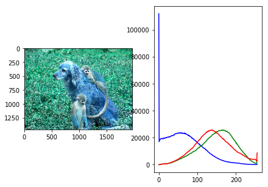

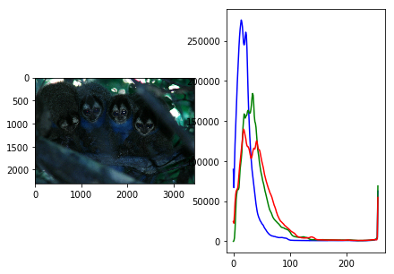

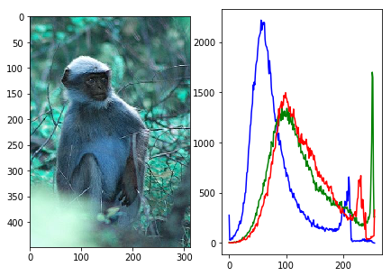

```python
def genrate_hist(img):
   color = ('b','g','r')
   histr = []
   for channel,col in enumerate(color):
           print(type(channel))
           histr1 = cv2.calcHist([img],[channel],None,[256],[0,256])
           histr.append(histr1)
   return histr

col = ('b','g','r')
img0=cv2.imread('./training/training/n0/n0018.jpg')
img1=cv2.imread('./training/training/n1/n1017.jpg')
img2=cv2.imread('./training/training/n2/n2017.jpg')
img3=cv2.imread('./training/training/n3/n3020.jpg')
img4=cv2.imread('./training/training/n4/n4016.jpg')
img5=cv2.imread('./training/training/n5/n5018.jpg')
img6=cv2.imread('./training/training/n6/n6016.jpg')
img7=cv2.imread('./training/training/n7/n702.jpg')
img8=cv2.imread('./training/training/n8/n808.jpg')
img9=cv2.imread('./training/training/n9/n915.jpg')

def genrate_hist(image):
   color = ('b','g','r')
   fig = plt.figure(figsize=(7,5))
   ax = fig.add_subplot(1, 2, 1)
   ax.imshow(image)
   for channel,col in enumerate(color):
           histr = cv2.calcHist([image],[channel],None,[256],[0,256])
           ax1 = fig.add_subplot(1, 2, 2)
           ax1.plot(histr,color = col)
   plt.show()



genrate_hist(img0)
genrate_hist(img1)
genrate_hist(img2)
genrate_hist(img3)
genrate_hist(img4)
genrate_hist(img5)
genrate_hist(img6)
genrate_hist(img7)
genrate_hist(img8)
genrate_hist(img9)
```

```python
import cv2
print(img1.shape)
print(img0.shape)
```

```
(423, 650, 3)
(367, 550, 3)
```

if you look at the data distribution of each type of image.. the distribution of colors changing with type of monkey.

So colour of image is going to play important role for classifying the species type.

The monkey with white color are having good spike in distribution in Red and blue green data

The amount of red green and blue combinations are varying as per colour of monkey... there are some distrabences with other pictures like dog trees and leaves

so looking at the data it seems we need to give more importance to colour. we cannot use grey scale

[figure not shown]

```python
img_2=cv2.imread('./training/training/n9/n9016.jpg')
plt.imshow(img_2)
```

Data augumentation starts here

Since the number of images are less. We will be using data augmentation. So this help in identifying the image in different locations in a frame and handles data imbalance in diffrent classes

In classification technique when the data belonging to one class is very less compared to other class. With the imbalance in data the model can be more biased and inaccurate. The class which is having more data it will become overfit And less data class become underfit So to avoid this I will be using Imagegenator from keras which will take the traing dir (which contains sub dir per class)

```python
from keras.preprocessing.image import ImageDataGenerator,img_to_array, load_img
##Image Genarator is used to genrate images datset from folder and also will normlize teh data with rescale of 1/255
datagen = ImageDataGenerator(
        rescale=1./255,
        rotation_range=40,
        width_shift_range=0.2,
        height_shift_range=0.2,
        shear_range=0.2,
        zoom_range=0.2,
        horizontal_flip=True,
fill_mode='nearest')
```

```python
testdatagen = ImageDataGenerator(rescale=1./255)
```

```python
#import PIL
#img1 = load_img('./training/training/n9/n9016.jpg')
#imga = img_to_array(img1)
#img2 = imga.reshape((1,) +imga.shape)
#i = 0
#for batch in datagen.flow(img2,save_to_dir='preview', save_prefix='monkey', save_format='jpeg'):
#    i += 1
#    if i > 50:
#        break
```

```python
#hyper-parameters
#lets resize the image to 150x150px
height=150
width=150
channels=3
seed=1337
batch_size = 64
num_classes = 10
epochs = 20
```

#### dataset will be genrated using the image Genarator by keras

follow the below link for more details https://keras.io/preprocessing/image/

```python
train_generator = datagen.flow_from_directory(train_dir,
                                                    target_size=(height,width),
                                                    batch_size=batch_size,
                                                    seed=seed,
                                                    shuffle=True,
                                                    class_mode='categorical')
```

```
Found 1097 images belonging to 10 classes.
```

```python
test_generator = testdatagen.flow_from_directory(test_dir,
                                                  target_size=(height,width),
                                                  batch_size=batch_size,
                                                  seed=seed,
                                                  shuffle=False,
                                                  class_mode='categorical')
```

```
Found 272 images belonging to 10 classes.
```

```python
print(test_generator.samples)
print(train_generator.samples)
```

```
272
1097
```

# Algorithms and Techniques

### Simple CNN model

The CNN model are used for most of the computer vision probelem.

In MLP we use vector by flatting the matrix input for image.. But that needs more training and computatation power.

Instead we break the matrix in to very small matrix and give it to the next layer which we call local connected layer

For image recognisation connected layers make more sense than the simple neural net.

So we use small matrix (filter ) move over the image and create new matrix from it.

then we will use the activation function just like perceptrons which will activate the nodes having more relvenet info.

then we reduce the size of matrix in next layer by using pooling layers ..

Then we continue this process till next few layers and then we flatten the matrix to a vector and give it to fully connected layer..

Then we will use softmax function which will geive a probablity that this image belongs to this class

How CNN works

CNN uses filters which will look like small boxes (as specified by user 2x3 or 3x3 so on ) and move over the image and try to find patterns in the following way in diffrent layers

layer1 : first layer of our CNN clearly picks out very simple shapes and patterns like lines and blobs.

layer2 : second layer of the CNN captures complex ideas. circles , stripes , and rectangles

layer3 and so on : picks out complex combinations of features from the second layer things like grids, and honeycombs

The simple CNN model that i am going to use is

2 Conv layers

2 Max pooling layer

2 FC layer

Also i am going to use other deeplearning algorithms ResNet,inception which are famous on image detection

## Inception

The Inception network was an important milestone in the development of CNN classifiers. Prior to its inception, most popular CNNs just stacked convolution layers deeper and deeper, hoping to get better performance.

Inception made the network wider than deeper.

What that means is using different size filters to caputre features this helps to caputre the same image with different sizes and image in different locations

This makes things more computational challenging. So they introduced 1x1 filters for dim reduction before 3x3 or 5x5

## Resnet :

Resnet is one of the best algorithm for training deep neural networks..

One of the main issue we face while training deep network is vanishing gradients.. resnet sloves this issue by introducing the shotcuts (identity functions ) to its erlier layers Which means the gradients back propagates through the shortcut connections.

This helps to train the network which are deeper.

this also helps in reducing thr training erorors

# BenchMark

### Benchmark Model

```python
from keras.models import Sequential
from keras.layers import Conv2D, MaxPooling2D, Activation, Dropout, Flatten, Dense
model = Sequential()
model.add(Conv2D(32, (3, 3), input_shape=(150, 150, 3)))
model.add(Activation('relu'))
model.add(MaxPooling2D(pool_size=(2, 2)))
model.add(Conv2D(32, (3, 3)))
model.add(Activation('relu'))
model.add(MaxPooling2D(pool_size=(2, 2)))
model.add(Flatten())
model.add(Dense(512))
model.add(Activation('relu'))
model.add(Dropout(0.5))
model.add(Dense(num_classes))
model.add(Activation('softmax'))
```

[output not shown]

```python
train_num = train_generator.samples
test_num = test_generator.samples
```

```python
model.compile(optimizer='adam',
              loss='categorical_crossentropy',
              metrics=['accuracy'])
model.summary()
```

```
_________________________________________________________________
Layer (type)                 Output Shape              Param #
=================================================================
conv2d_1 (Conv2D)            (None, 148, 148, 32)      896
_________________________________________________________________
activation_1 (Activation)    (None, 148, 148, 32)      0
_________________________________________________________________
max_pooling2d_1 (MaxPooling2 (None, 74, 74, 32)        0
_________________________________________________________________
conv2d_2 (Conv2D)            (None, 72, 72, 32)        9248
_________________________________________________________________
activation_2 (Activation)    (None, 72, 72, 32)        0
_________________________________________________________________
max_pooling2d_2 (MaxPooling2 (None, 36, 36, 32)        0
_________________________________________________________________
flatten_1 (Flatten)          (None, 41472)             0
_________________________________________________________________
dense_1 (Dense)              (None, 512)               21234176
_________________________________________________________________
activation_3 (Activation)    (None, 512)               0
_________________________________________________________________
dropout_1 (Dropout)          (None, 512)               0
_________________________________________________________________
dense_2 (Dense)              (None, 10)                5130
_________________________________________________________________
activation_4 (Activation)    (None, 10)                0
=================================================================
Total params: 21,249,450
Trainable params: 21,249,450
Non-trainable params: 0
_________________________________________________________________
```

```python
from keras.callbacks import ModelCheckpoint, EarlyStopping
import os
filepath=str(os.getcwd()+"/model.h5f")
checkpoint = ModelCheckpoint(filepath, monitor='val_acc', verbose=1, save_best_only=True, mode='max')
```

```python
callbacks_list = [checkpoint]
history = model.fit_generator(train_generator,
                              steps_per_epoch= train_num // batch_size,
                              epochs=epochs,
                              validation_data=train_generator,
                              validation_steps= test_num // batch_size,
                              callbacks=callbacks_list,
                              verbose = 1
                             )
```

```
WARNING:tensorflow:From C:\Users\gr925a\AppData\Local\Continuum\anaconda3\envs\tensor\lib\site-packages\tensorflow\python\ops\math_ops.py:3066: to_int32 (from tensorflow.python.ops.math_ops) is deprecated and will be removed in a future version.
Instructions for updating:
Use tf.cast instead.

Epoch 00001: val_acc improved from -inf to 0.09766, saving model to C:\Users\gr925a\Downloads\10-monkey-species/model.h5f

Epoch 00002: val_acc improved from 0.09766 to 0.27734, saving model to C:\Users\gr925a\Downloads\10-monkey-species/model.h5f

Epoch 00003: val_acc improved from 0.27734 to 0.30859, saving model to C:\Users\gr925a\Downloads\10-monkey-species/model.h5f

Epoch 00004: val_acc improved from 0.30859 to 0.35323, saving model to C:\Users\gr925a\Downloads\10-monkey-species/model.h5f

Epoch 00005: val_acc improved from 0.35323 to 0.39041, saving model to C:\Users\gr925a\Downloads\10-monkey-species/model.h5f

Epoch 00006: val_acc improved from 0.39041 to 0.46484, saving model to C:\Users\gr925a\Downloads\10-monkey-species/model.h5f

Epoch 00007: val_acc improved from 0.46484 to 0.50781, saving model to C:\Users\gr925a\Downloads\10-monkey-species/model.h5f

Epoch 00008: val_acc improved from 0.50781 to 0.54297, saving model to C:\Users\gr925a\Downloads\10-monkey-species/model.h5f

Epoch 00009: val_acc improved from 0.54297 to 0.56250, saving model to C:\Users\gr925a\Downloads\10-monkey-species/model.h5f

Epoch 00010: val_acc did not improve from 0.56250

Epoch 00011: val_acc did not improve from 0.56250

Epoch 00012: val_acc did not improve from 0.56250

Epoch 00013: val_acc did not improve from 0.56250

Epoch 00014: val_acc did not improve from 0.56250

Epoch 00015: val_acc improved from 0.56250 to 0.58203, saving model to C:\Users\gr925a\Downloads\10-monkey-species/model.h5f

Epoch 00016: val_acc improved from 0.58203 to 0.58706, saving model to C:\Users\gr925a\Downloads\10-monkey-species/model.h5f

Epoch 00017: val_acc did not improve from 0.58706

Epoch 00018: val_acc improved from 0.58706 to 0.61719, saving model to C:\Users\gr925a\Downloads\10-monkey-species/model.h5f

Epoch 00019: val_acc did not improve from 0.61719

Epoch 00020: val_acc did not improve from 0.61719
```

#### using CNN to predict model (benchmark model)

we will try to predict the accurecy of model.

Since the last layer will be using softmax function. it will give preobabilities that each image belongs to that 10 classes.

We need to take the class which is having high probablity

```python
test_prediction = model.predict_generator(test_generator,test_num // batch_size + 1)
```

```python
test_prediction_classes  = np.argmax(test_prediction,axis = 1)
```

```python
test_prediction
```

```
array([[2.84309417e-01, 1.94534383e-04, 3.37930942e-06, ...,
        2.17128181e-05, 3.17057391e-04, 6.24457657e-01],
       [1.69637054e-01, 1.81646675e-01, 1.31378463e-03, ...,
        2.46800780e-02, 3.60036902e-02, 5.62876999e-01],
       [2.34195113e-01, 6.45027962e-04, 1.57011152e-06, ...,
        2.55381281e-04, 5.30501083e-03, 6.95030034e-01],
       ...,
       [1.31470844e-01, 1.74934359e-03, 2.33140372e-06, ...,
        4.31092660e-04, 3.42209707e-03, 6.77871287e-01],
       [2.87794977e-01, 1.49214035e-02, 2.72718142e-04, ...,
        1.77491468e-03, 1.90034192e-02, 5.43525994e-01],
       [2.59283155e-01, 2.59707076e-03, 1.76908852e-05, ...,
        1.68759230e-04, 4.27284482e-04, 7.10533798e-01]], dtype=float32)
```

```python
print(test_prediction_classes)
print(test_generator.classes)
```

```
[9 9 9 5 0 9 3 9 1 0 9 9 1 9 9 9 0 9 0 0 9 9 5 0 5 0 9 9 0 0 2 0 0 5 0 0 0
 0 0 9 0 0 3 7 3 6 1 1 1 4 1 5 7 1 1 3 4 1 1 1 1 1 8 3 1 3 1 1 1 3 2 8 2 2
 2 2 3 3 2 2 2 2 2 2 2 2 2 2 2 2 2 2 2 2 2 2 2 1 3 3 8 3 3 6 3 6 3 8 3 3 3
 3 3 9 3 3 3 6 3 6 3 3 8 3 3 3 3 4 5 4 4 4 4 4 4 4 8 4 4 4 8 4 4 3 4 4 4 4
 5 7 4 3 4 0 3 3 0 5 6 5 5 3 0 9 5 5 5 9 1 5 5 5 0 5 9 9 0 5 7 5 3 0 6 6 6
 5 6 4 6 6 6 6 6 1 6 6 1 6 1 6 6 5 3 3 1 1 1 4 4 8 5 4 5 7 6 1 7 4 7 1 4 7
 7 7 2 1 1 8 7 7 8 6 7 1 1 8 8 3 8 8 8 4 8 8 8 8 8 8 8 8 8 8 8 8 8 8 8 8 8
 8 4 4 9 9 3 9 9 9 9 9 9 9]
[0 0 0 0 0 0 0 0 0 0 0 0 0 0 0 0 0 0 0 0 0 0 0 0 0 0 1 1 1 1 1 1 1 1 1 1 1
 1 1 1 1 1 1 1 1 1 1 1 1 1 1 1 1 1 2 2 2 2 2 2 2 2 2 2 2 2 2 2 2 2 2 2 2 2
 2 2 2 2 2 2 2 3 3 3 3 3 3 3 3 3 3 3 3 3 3 3 3 3 3 3 3 3 3 3 3 3 3 3 3 3 3
 4 4 4 4 4 4 4 4 4 4 4 4 4 4 4 4 4 4 4 4 4 4 4 4 4 4 5 5 5 5 5 5 5 5 5 5 5
 5 5 5 5 5 5 5 5 5 5 5 5 5 5 5 5 5 6 6 6 6 6 6 6 6 6 6 6 6 6 6 6 6 6 6 6 6
 6 6 6 6 6 6 7 7 7 7 7 7 7 7 7 7 7 7 7 7 7 7 7 7 7 7 7 7 7 7 7 7 7 7 8 8 8
 8 8 8 8 8 8 8 8 8 8 8 8 8 8 8 8 8 8 8 8 8 8 8 8 9 9 9 9 9 9 9 9 9 9 9 9 9
 9 9 9 9 9 9 9 9 9 9 9 9 9]
```

```python
confusion_mtx = confusion_matrix(y_true = test_generator.classes,y_pred = test_prediction_classes)
```

```python
loss, acc = model.evaluate_generator(test_generator,test_num // batch_size + 1)
print(loss,acc)
```

```
1.077648317112642 0.6323529411764706
```

##### printing the confusion matrix of Benchmark Model

i have used the confusion matrix code from below github https://github.com/wcipriano/pretty-print-confusion-matrix/blob/master/confusion_matrix_pretty_print.py

```python
np.unique(test_generator.classes)
```

```
array([0, 1, 2, 3, 4, 5, 6, 7, 8, 9])
```

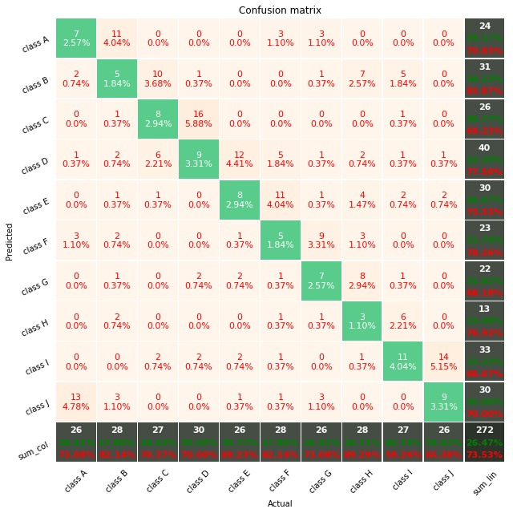

```python
import confusion_matrix_pretty_print
confusion_matrix_pretty_print.plot_confusion_matrix_from_data(test_generator.classes,test_prediction_classes)
```

### confusion matrix data exploration

from the confusionmatrix it is clear that there there are false postives and false negitives..

False positive: the model says it belongs to class A . but it belongs to some other class False Negitive: the model says it does not belong to class A. but actually it belongs to class A

# 3. Methodology

### Data preprocessing:

Preprocessing is preparing the data for training

Randomizing the data :

Train/validation sets with labels

Normalize the data

All the above steps are done by the image genarator module of keras. So the data will be randomized  
preprocess_input will normalize the data and make it ready for the module flow_from_directory will create the dataset and labelset needed for training and validation

### Implementation:

the implementation of the algorithm has 2 stages

```
Training the classifier
Creating the module which will detect the type of specifies if image is given
```

During the first stage, the classifier was trained on the preprocessed training data. This was done in a Jupyter notebook and can be further divided into the following steps:

1. Load both the training and validation images into memory
2. Define the CNN network architectures

   ```
      How many  conv layers / pool layers / FC layers
   ```

3. defining the loss/ accuracy function
4. monitor the training /validation errors during the epochs
5. if accuracy less tune parameters and retrain
6. once accuracy is reached we are done

In second stage we will build the function which we will use the train model to detect the future images

```python
from keras.applications.inception_v3 import preprocess_input
```

```python
train_data_gen_INCEPTION=ImageDataGenerator(
                              preprocessing_function=preprocess_input,
                              rotation_range=35,
                              width_shift_range=0.2,
                              height_shift_range=0.2,
                              shear_range=0.2,
                              horizontal_flip=True,
                              fill_mode='nearest'
                             )
```

```python
test_data_gen_incpetion = ImageDataGenerator(
                                       preprocessing_function=preprocess_input
                                      )
```

```python
train_gen_incp = train_data_gen_INCEPTION.flow_from_directory(train_dir,
                                            target_size=(height,width),
                                                               seed=seed,
                                            batch_size=batch_size,
                                            shuffle=True,
                                            class_mode="categorical")
test_gen_incp = test_data_gen_incpetion.flow_from_directory(test_dir,
                                                    target_size=(height,width),
                                                    batch_size = batch_size,
                                                            seed=seed,
                                                    shuffle=False,
                                                    class_mode="categorical")
```

```
Found 1097 images belonging to 10 classes.
Found 272 images belonging to 10 classes.
```

```python
train_count=train_gen_incp.samples
val_count=test_gen_incp.samples
steps_per_epoch=train_count//batch_size
steps_per_epoch
```

```
17
```

```python
from keras.applications import InceptionV3
from keras.models import Sequential
from keras.layers import Dense, GlobalAveragePooling2D, Dropout
model_incp=Sequential()
# add inception pretrained model, the wieghts 80Mb
model_incp.add(InceptionV3(include_top=False,
                      pooling='avg',
                      weights='imagenet'))
# use relu as activation function "vanishing gradiends" :)
model_incp.add(Dense(512, activation="relu"))
# add drop out to avoid overfitting
model_incp.add(Dropout(0.5))
model_incp.add(Dense(num_classes, activation="softmax"))
```

```python
model_incp.layers[0].trainable=False
model_incp.layers[0].summary()
```

```
__________________________________________________________________________________________________
Layer (type)                    Output Shape         Param #     Connected to
==================================================================================================
input_2 (InputLayer)            (None, None, None, 3 0
__________________________________________________________________________________________________
conv2d_97 (Conv2D)              (None, None, None, 3 864         input_2[0][0]
__________________________________________________________________________________________________
batch_normalization_95 (BatchNo (None, None, None, 3 96          conv2d_97[0][0]
__________________________________________________________________________________________________
activation_99 (Activation)      (None, None, None, 3 0           batch_normalization_95[0][0]
__________________________________________________________________________________________________
conv2d_98 (Conv2D)              (None, None, None, 3 9216        activation_99[0][0]
__________________________________________________________________________________________________
batch_normalization_96 (BatchNo (None, None, None, 3 96          conv2d_98[0][0]
__________________________________________________________________________________________________
activation_100 (Activation)     (None, None, None, 3 0           batch_normalization_96[0][0]
__________________________________________________________________________________________________
conv2d_99 (Conv2D)              (None, None, None, 6 18432       activation_100[0][0]
__________________________________________________________________________________________________
batch_normalization_97 (BatchNo (None, None, None, 6 192         conv2d_99[0][0]
__________________________________________________________________________________________________
activation_101 (Activation)     (None, None, None, 6 0           batch_normalization_97[0][0]
__________________________________________________________________________________________________
max_pooling2d_7 (MaxPooling2D)  (None, None, None, 6 0           activation_101[0][0]
__________________________________________________________________________________________________
conv2d_100 (Conv2D)             (None, None, None, 8 5120        max_pooling2d_7[0][0]
__________________________________________________________________________________________________
batch_normalization_98 (BatchNo (None, None, None, 8 240         conv2d_100[0][0]
__________________________________________________________________________________________________
activation_102 (Activation)     (None, None, None, 8 0           batch_normalization_98[0][0]
__________________________________________________________________________________________________
conv2d_101 (Conv2D)             (None, None, None, 1 138240      activation_102[0][0]
__________________________________________________________________________________________________
batch_normalization_99 (BatchNo (None, None, None, 1 576         conv2d_101[0][0]
__________________________________________________________________________________________________
activation_103 (Activation)     (None, None, None, 1 0           batch_normalization_99[0][0]
__________________________________________________________________________________________________
max_pooling2d_8 (MaxPooling2D)  (None, None, None, 1 0           activation_103[0][0]
__________________________________________________________________________________________________
conv2d_105 (Conv2D)             (None, None, None, 6 12288       max_pooling2d_8[0][0]
```

[output cut: 611 more lines]

```
                                                                 activation_191[0][0]
__________________________________________________________________________________________________
activation_192 (Activation)     (None, None, None, 1 0           batch_normalization_188[0][0]
__________________________________________________________________________________________________
mixed10 (Concatenate)           (None, None, None, 2 0           activation_184[0][0]
                                                                 mixed9_1[0][0]
                                                                 concatenate_4[0][0]
                                                                 activation_192[0][0]
__________________________________________________________________________________________________
global_average_pooling2d_2 (Glo (None, 2048)         0           mixed10[0][0]
==================================================================================================
Total params: 21,802,784
Trainable params: 0
Non-trainable params: 21,802,784
__________________________________________________________________________________________________
```

```python
model_incp.compile(loss="categorical_crossentropy",
              optimizer='adam',
              metrics=["accuracy"])
model_incp_history = model_incp.fit_generator(train_gen_incp,
                                    steps_per_epoch=steps_per_epoch,
                                    epochs=32,
                                    validation_data=train_gen_incp,
                                    validation_steps=test_num // batch_size
                                   )
model_incp.save('incept_adv.h5')
```

```python
test_prediction_incp = model_incp.predict_generator(test_gen_incp,test_num // batch_size + 1)
```

```python
loss1, acc1 = model_incp.evaluate_generator(test_gen_incp,test_num // batch_size + 1)
print(loss1,acc1)
```

```
0.6658222780508154 0.8786764705882353
```

```python
test_prediction_classes_incp  = np.argmax(test_prediction_incp,axis = 1)
```

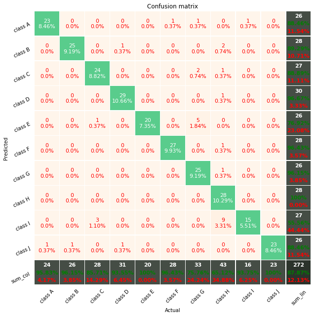

```python
confusion_matrix_pretty_print.plot_confusion_matrix_from_data(test_prediction_classes_incp,test_gen_incp.classes)
```

### Cobnfusion matrix of Inception

I donot have GPU based processor.. so probably if we increase the epoch we can see better results

```python
test_prediction_classes_incp
```

```
array([0, 8, 0, 0, 6, 0, 0, 0, 0, 0, 0, 0, 0, 0, 5, 0, 0, 0, 0, 0, 0, 0,
       0, 0, 0, 0, 1, 1, 1, 1, 1, 1, 1, 1, 1, 3, 1, 1, 1, 1, 7, 1, 1, 1,
       1, 1, 7, 1, 1, 1, 1, 1, 1, 1, 2, 6, 2, 2, 2, 2, 2, 2, 2, 6, 2, 2,
       2, 7, 2, 2, 2, 2, 2, 2, 2, 2, 2, 2, 2, 2, 2, 3, 3, 3, 3, 3, 3, 3,
       3, 3, 3, 3, 3, 3, 3, 3, 3, 7, 3, 3, 3, 3, 3, 3, 3, 3, 3, 3, 3, 3,
       3, 6, 4, 4, 4, 4, 4, 4, 4, 4, 4, 4, 4, 4, 6, 2, 6, 6, 4, 4, 4, 4,
       4, 4, 4, 6, 4, 5, 5, 5, 5, 5, 5, 5, 5, 5, 5, 5, 5, 5, 5, 5, 5, 7,
       5, 5, 5, 5, 5, 5, 5, 5, 5, 5, 5, 6, 6, 6, 6, 7, 6, 6, 6, 6, 6, 6,
       6, 6, 6, 6, 6, 6, 6, 6, 6, 6, 6, 6, 6, 6, 6, 7, 7, 7, 7, 7, 7, 7,
       7, 7, 7, 7, 7, 7, 7, 7, 7, 7, 7, 7, 7, 7, 7, 7, 7, 7, 7, 7, 7, 8,
       2, 7, 8, 8, 7, 7, 8, 7, 8, 8, 7, 2, 8, 8, 8, 8, 7, 8, 8, 8, 7, 2,
       7, 7, 8, 8, 9, 9, 1, 9, 9, 9, 9, 3, 9, 9, 9, 9, 9, 9, 9, 9, 9, 9,
       9, 9, 9, 9, 9, 9, 9, 0], dtype=int64)
```

```python
test_gen_incp.classes
```

```
array([0, 0, 0, 0, 0, 0, 0, 0, 0, 0, 0, 0, 0, 0, 0, 0, 0, 0, 0, 0, 0, 0,
       0, 0, 0, 0, 1, 1, 1, 1, 1, 1, 1, 1, 1, 1, 1, 1, 1, 1, 1, 1, 1, 1,
       1, 1, 1, 1, 1, 1, 1, 1, 1, 1, 2, 2, 2, 2, 2, 2, 2, 2, 2, 2, 2, 2,
       2, 2, 2, 2, 2, 2, 2, 2, 2, 2, 2, 2, 2, 2, 2, 3, 3, 3, 3, 3, 3, 3,
       3, 3, 3, 3, 3, 3, 3, 3, 3, 3, 3, 3, 3, 3, 3, 3, 3, 3, 3, 3, 3, 3,
       3, 4, 4, 4, 4, 4, 4, 4, 4, 4, 4, 4, 4, 4, 4, 4, 4, 4, 4, 4, 4, 4,
       4, 4, 4, 4, 4, 5, 5, 5, 5, 5, 5, 5, 5, 5, 5, 5, 5, 5, 5, 5, 5, 5,
       5, 5, 5, 5, 5, 5, 5, 5, 5, 5, 5, 6, 6, 6, 6, 6, 6, 6, 6, 6, 6, 6,
       6, 6, 6, 6, 6, 6, 6, 6, 6, 6, 6, 6, 6, 6, 6, 7, 7, 7, 7, 7, 7, 7,
       7, 7, 7, 7, 7, 7, 7, 7, 7, 7, 7, 7, 7, 7, 7, 7, 7, 7, 7, 7, 7, 8,
       8, 8, 8, 8, 8, 8, 8, 8, 8, 8, 8, 8, 8, 8, 8, 8, 8, 8, 8, 8, 8, 8,
       8, 8, 8, 8, 9, 9, 9, 9, 9, 9, 9, 9, 9, 9, 9, 9, 9, 9, 9, 9, 9, 9,
       9, 9, 9, 9, 9, 9, 9, 9])
```

```python
confusion_mtx_incp = confusion_matrix(y_true = test_gen_incp.classes,y_pred = test_prediction_classes_incp)
```

```python
confusion_mtx_incp
```

```
array([[23,  0,  0,  0,  0,  1,  1,  0,  1,  0],
       [ 0, 25,  0,  1,  0,  0,  0,  2,  0,  0],
       [ 0,  0, 24,  0,  0,  0,  2,  1,  0,  0],
       [ 0,  0,  0, 29,  0,  0,  0,  1,  0,  0],
       [ 0,  0,  1,  0, 20,  0,  5,  0,  0,  0],
       [ 0,  0,  0,  0,  0, 27,  0,  1,  0,  0],
       [ 0,  0,  0,  0,  0,  0, 25,  1,  0,  0],
       [ 0,  0,  0,  0,  0,  0,  0, 28,  0,  0],
       [ 0,  0,  3,  0,  0,  0,  0,  9, 15,  0],
       [ 1,  1,  0,  1,  0,  0,  0,  0,  0, 23]], dtype=int64)
```

```python
test_prediction_incp
```

```
array([[9.98193324e-01, 3.12871489e-05, 1.22250232e-04, ...,
        1.62392462e-04, 8.79710715e-04, 1.00405916e-04],
       [6.13101758e-02, 5.49225602e-04, 2.01508174e-05, ...,
        5.33371745e-03, 7.67796099e-01, 1.19781792e-02],
       [9.99999762e-01, 4.69757485e-15, 6.91216390e-11, ...,
        2.85134936e-11, 2.03514167e-11, 7.50671560e-08],
       ...,
       [2.57614627e-02, 2.17048567e-11, 3.90972689e-14, ...,
        4.48358635e-13, 3.56272412e-12, 9.73693967e-01],
       [1.17356835e-09, 5.48893411e-04, 1.71719194e-10, ...,
        2.27832281e-10, 9.85765636e-11, 9.99451101e-01],
       [9.98286426e-01, 1.11683340e-09, 1.83213604e-06, ...,
        2.54567585e-08, 4.84814180e-08, 1.10077346e-03]], dtype=float32)
```

### Lets plot the training and validation errors

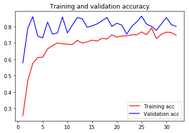

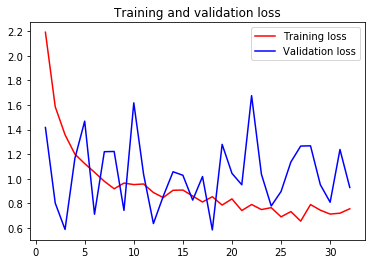

```python
acc = model_incp_history.history['acc']
val_acc = model_incp_history.history['val_acc']
loss = model_incp_history.history['loss']
val_loss = model_incp_history.history['val_loss']
epochs = range(1, len(acc) + 1)

import matplotlib.pyplot as plt

plt.title('Training and validation accuracy')
plt.plot(epochs, acc, 'red', label='Training acc')
plt.plot(epochs, val_acc, 'blue', label='Validation acc')
plt.legend()

plt.figure()
plt.title('Training and validation loss')
plt.plot(epochs, loss, 'red', label='Training loss')
plt.plot(epochs, val_loss, 'blue', label='Validation loss')

plt.legend()

plt.show()
```

### lets try RESNET

```python
from keras.applications.resnet50 import preprocess_input
```

```python
train_data_gen_resnet50=ImageDataGenerator(
                              preprocessing_function=preprocess_input,
                              rotation_range=35,
                              width_shift_range=0.2,
                              height_shift_range=0.2,
                              shear_range=0.2,
                              horizontal_flip=True,
                              fill_mode='nearest'
                             )
test_data_gen_resnet50 = ImageDataGenerator(
                                       preprocessing_function=preprocess_input
                                      )

train_gen_resnet50 = train_data_gen_resnet50.flow_from_directory(train_dir,
                                            target_size=(height,width),
                                                               seed=seed,
                                            batch_size=batch_size,
                                            shuffle=True,
                                            class_mode="categorical")
test_gen_resnet50 = test_data_gen_resnet50.flow_from_directory(test_dir,
                                                    target_size=(height,width),
                                                    batch_size = batch_size,
                                                            seed=seed,
                                                    shuffle=False,
                                                    class_mode="categorical")
```

```
Found 1097 images belonging to 10 classes.
Found 272 images belonging to 10 classes.
```

```python
train_count=train_gen_resnet50.samples
val_count=test_gen_resnet50.samples
steps_per_epoch=train_count//batch_size
steps_per_epoch
```

```
17
```

```python
from keras.applications import ResNet50
from keras.models import Sequential
from keras.layers import Dense, GlobalAveragePooling2D, Dropout
```

```python
model_resnet=Sequential()
# add resnet50  pretrained model, the wieghts 80Mb
model_resnet.add(ResNet50(include_top=False,
                      pooling='avg',input_shape=(150,150,3),
                      weights='imagenet'))
# use relu as activation function "vanishing gradiends" :)
model_resnet.add(Dense(512, activation="relu"))
# add drop out to avoid overfitting
model_resnet.add(Dropout(0.5))
model_resnet.add(Dense(num_classes, activation="softmax"))
```

```python
model_resnet.layers[0].trainable=False
model_resnet.layers[0].summary()
```

```
__________________________________________________________________________________________________
Layer (type)                    Output Shape         Param #     Connected to
==================================================================================================
input_3 (InputLayer)            (None, 150, 150, 3)  0
__________________________________________________________________________________________________
conv1_pad (ZeroPadding2D)       (None, 156, 156, 3)  0           input_3[0][0]
__________________________________________________________________________________________________
conv1 (Conv2D)                  (None, 75, 75, 64)   9472        conv1_pad[0][0]
__________________________________________________________________________________________________
bn_conv1 (BatchNormalization)   (None, 75, 75, 64)   256         conv1[0][0]
__________________________________________________________________________________________________
activation_193 (Activation)     (None, 75, 75, 64)   0           bn_conv1[0][0]
__________________________________________________________________________________________________
pool1_pad (ZeroPadding2D)       (None, 77, 77, 64)   0           activation_193[0][0]
__________________________________________________________________________________________________
max_pooling2d_11 (MaxPooling2D) (None, 38, 38, 64)   0           pool1_pad[0][0]
__________________________________________________________________________________________________
res2a_branch2a (Conv2D)         (None, 38, 38, 64)   4160        max_pooling2d_11[0][0]
__________________________________________________________________________________________________
bn2a_branch2a (BatchNormalizati (None, 38, 38, 64)   256         res2a_branch2a[0][0]
__________________________________________________________________________________________________
activation_194 (Activation)     (None, 38, 38, 64)   0           bn2a_branch2a[0][0]
__________________________________________________________________________________________________
res2a_branch2b (Conv2D)         (None, 38, 38, 64)   36928       activation_194[0][0]
__________________________________________________________________________________________________
bn2a_branch2b (BatchNormalizati (None, 38, 38, 64)   256         res2a_branch2b[0][0]
__________________________________________________________________________________________________
activation_195 (Activation)     (None, 38, 38, 64)   0           bn2a_branch2b[0][0]
__________________________________________________________________________________________________
res2a_branch2c (Conv2D)         (None, 38, 38, 256)  16640       activation_195[0][0]
__________________________________________________________________________________________________
res2a_branch1 (Conv2D)          (None, 38, 38, 256)  16640       max_pooling2d_11[0][0]
__________________________________________________________________________________________________
bn2a_branch2c (BatchNormalizati (None, 38, 38, 256)  1024        res2a_branch2c[0][0]
__________________________________________________________________________________________________
bn2a_branch1 (BatchNormalizatio (None, 38, 38, 256)  1024        res2a_branch1[0][0]
__________________________________________________________________________________________________
add_1 (Add)                     (None, 38, 38, 256)  0           bn2a_branch2c[0][0]
                                                                 bn2a_branch1[0][0]
__________________________________________________________________________________________________
```

[output cut: 320 more lines]

```
res5c_branch2c (Conv2D)         (None, 5, 5, 2048)   1050624     activation_240[0][0]
__________________________________________________________________________________________________
bn5c_branch2c (BatchNormalizati (None, 5, 5, 2048)   8192        res5c_branch2c[0][0]
__________________________________________________________________________________________________
add_16 (Add)                    (None, 5, 5, 2048)   0           bn5c_branch2c[0][0]
                                                                 activation_238[0][0]
__________________________________________________________________________________________________
activation_241 (Activation)     (None, 5, 5, 2048)   0           add_16[0][0]
__________________________________________________________________________________________________
global_average_pooling2d_3 (Glo (None, 2048)         0           activation_241[0][0]
==================================================================================================
Total params: 23,587,712
Trainable params: 0
Non-trainable params: 23,587,712
__________________________________________________________________________________________________
```

```python
model_resnet.compile(loss="categorical_crossentropy",
              optimizer='adam',
              metrics=["accuracy"])
model_resnet_history = model_resnet.fit_generator(train_gen_resnet50,
                                    steps_per_epoch=steps_per_epoch,
                                    epochs=32,
                                    validation_data=train_gen_resnet50,
                                    validation_steps=test_num // batch_size
                                   )
model_resnet.save('resnet50.h5')
```

```python
test_gen_resnet50 = test_data_gen_resnet50.flow_from_directory(test_dir,
                                                    target_size=(height,width),
                                                    batch_size = batch_size,
                                                            seed=seed,
                                                    shuffle=False,
                                                    class_mode="categorical")
```

```
Found 272 images belonging to 10 classes.
```

```python
test_prediction_resnet = model_resnet.predict_generator(test_gen_resnet50,test_num // batch_size + 1)
loss2, acc2 = model_resnet.evaluate_generator(test_gen_resnet50,test_num // batch_size + 1)
print(loss2,acc2)
```

```
0.56015972804059 0.9117647058823529
```

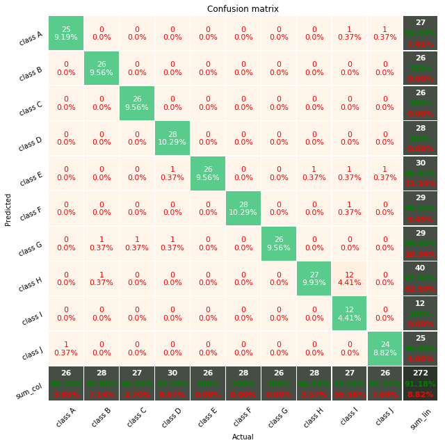

```python
test_prediction_classes_resnet  = np.argmax(test_prediction_resnet,axis = 1)
confusion_matrix_pretty_print.plot_confusion_matrix_from_data(test_gen_resnet50.classes, test_prediction_classes_resnet)
```

```python
print(test_prediction_classes_resnet )
```

```
[0 0 0 0 0 0 0 0 0 0 0 0 0 0 0 0 0 0 0 0 0 0 0 9 0 0 1 1 1 6 1 1 1 1 1 1 1
 1 1 1 1 1 1 1 1 1 7 1 1 1 1 1 1 1 2 2 2 2 6 2 2 2 2 2 2 2 2 2 2 2 2 2 2 2
 2 2 2 2 2 2 2 3 3 3 3 3 3 3 3 3 3 3 3 3 3 3 3 6 3 3 3 3 3 3 3 3 3 3 3 3 4
 4 4 4 4 4 4 4 4 4 4 4 4 4 4 4 4 4 4 4 4 4 4 4 4 4 4 5 5 5 5 5 5 5 5 5 5 5
 5 5 5 5 5 5 5 5 5 5 5 5 5 5 5 5 5 6 6 6 6 6 6 6 6 6 6 6 6 6 6 6 6 6 6 6 6
 6 6 6 6 6 6 7 7 7 7 7 7 7 7 7 7 7 7 7 4 7 7 7 7 7 7 7 7 7 7 7 7 7 7 7 7 7
 4 8 7 7 7 7 8 8 8 8 8 0 8 8 7 8 8 7 7 5 7 7 8 8 9 9 9 9 9 0 9 9 9 9 9 9 9
 9 9 9 4 9 9 9 9 9 9 9 9 9]
```

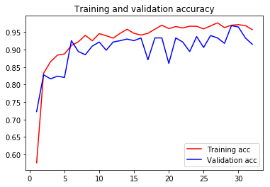

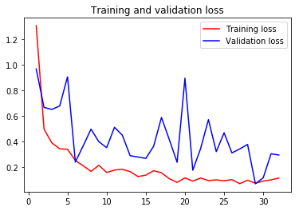

```python
acc_res = model_resnet_history.history['acc']
val_acc_res = model_resnet_history.history['val_acc']
loss_res = model_resnet_history.history['loss']
val_loss_res = model_resnet_history.history['val_loss']
epochs = range(1, len(acc) + 1)

import matplotlib.pyplot as plt

plt.title('Training and validation accuracy')
plt.plot(epochs, acc_res, 'red', label='Training acc')
plt.plot(epochs, val_acc_res, 'blue', label='Validation acc')
plt.legend()

plt.figure()
plt.title('Training and validation loss')
plt.plot(epochs, loss_res, 'red', label='Training loss')
plt.plot(epochs, val_loss_res, 'blue', label='Validation loss')

plt.legend()

plt.show()
```

#### Now building algorithm for detecting the species of monkey using the Restnet model

1 -- load the saved model

2 -- use it for prediction

```python
from keras.preprocessing import image
from keras.models import load_model
img_width, img_height =  150,150

#lets me load my model
my_model_resnet = load_model('resnet50.h5')
```

```python
def get_image(image_path):
    img = image.load_img(image_path, target_size=(img_width, img_height))
    x = image.img_to_array(img)
    x = np.expand_dims(x, axis=0)
    return  preprocess_input(x)
```

##### challenges faced

Data Imbalance:

```
One of the biggest issue that we need to deal with classification probelm is data imbalance . If number of images in one class is more than other class this creates overfitting/underfittin of that respective  class. We need to deal with data imbalance with data augmenation technique
```

Finding best gradient algorithm:

```
we have so many gradeint decent techniques that needs to be  checked and find the one which gives best results. The gradient algorithm supports below optimization techniques

Momentum
Nestrov accelarated grdient
Adagrad
Adadelta
RMSprop
Adam
Adamax
Nadam
Amsgrad

Choosing the best one for your model is tough task.  most of the time you end up with trail and error method.  The one i have choosen if ADAM Adaptive Moment Estimation (Adam) .. this technique uses adaptive learning rate for each paramter.  In addition to storing an exponentially decaying average of past squared gradients  like Adadelta and RMSprop, Adam also keeps an exponentially decaying average of past gradients.  Adam behaves like a heavy ball with friction, which thus prefers flat minima in the error surface.
more info can be found from
http://ruder.io/optimizing-gradient-descent/
```

Finding best algoritms in deep learning:

```
 We have so many deep learning techniques starting with

    Alexnet
    VGG
    Resnet
    Inception
    Xception


 Now choosing best algorithm  from them is going to be trail and error method.. each algorithm will have its own advantages and disadvantages..
 When you select models like vgg19 , resnet, incpetion and xception  they are deep and needs a lot computation for training ..

 The Inception network was an important milestone in the development of CNN classifiers. Prior to its inception (punintended), most popular CNNs just stacked convolution layers deeper and deeper, hoping to get better performance.

 Inception made the network wider than deeper.
 What that means is using different size filters to caputre   features this helps to caputre the  same image with different sizes  and image in different locations. This makes things more computational challenging. So  they introduced 1x1 filters for dim reduction before 3x3 or 5x5. This is useful for our model beacuse the monkey images are not properly placed. they are moved around the frame.

 Restnet : they are fast to train becasue of residual nets(shortcuts). this helps backpropagation of error fast..

 Xception : is going to be one of the other algorithm to try. beacuse it takes each input layer separatly..  that means diffrent fillters for diffrent channels of inputs.. this helps  good for color images  and images of diffrent color species.
```

Importnant points to be remembered for coding

```
    Dataaugementation : via Image generator
    Transfer learning : when you start the model training try to intilize weiights  with imagenet data. this makes traing fast
    Confusion Matrix:    you can use normal  scikit learn confuion matrix. But  the pretty print confusion matrix looks nice  and giving more details of data
```

###### Transfer Learning

Transfer learning involves taking a pre-trained neural network and adapting the neural network to a new, different data set.

We will be using imagenet weights

### Refinement

Intially we used the basic CNN model with 2 layers.. now the models that we are going to use now is Inception and Resent.

When we compare our basic model with these models. they will do better job beacuse

```
They have more layers -- this helps  algorithm to capture more complex features
using diffrent filters at diffrent stage helps to find more complex patterns
```

Techniques used:

```
  Data augmentation :  this helps to deal with data imbalance

  Gradient algortihm: used  Adam as optimizer to imporve model performence

  Algorithm:  from basic CNN we moved on using the  Resnet

 i used the transfer learning technique  of intilizing the  weights  for filters and conv/pooling layers
```

# 4. Results

### Model Evaluation and Validation

The final model is dervied using the resnet model.

Final model works like below:

```
 It takes image as input
 then data processing will happen (Resize of image,preprocessing of renet model  )
 then it will be sent to resent algorithm  and gets the best guess of class
 then it will output the class of the  image
```

Testing the model with unseen data

i have downloaded 4 monkey images from the internet and they are tested aginst the model.

One of the image (mokey 4) belongs to class Markku Kassila which is not even in the training list.. The model made guess and aligned to the species which has closet match

This model (resent model) trained using the data with data augumentation. so the training data has got images with lot of variation and rotation and zoon.

So this makes model more robust as it got trained well enough

```python
img_path =  './monkey1.jpg'
image1 = get_image(img_path)

predicted_out=model_resnet.predict(image1)
pred=np.argmax(predicted_out,axis = 1)
print(pred)
```

```
[6]
```

```python
img_path =  './monkey2.jpg'
image1 = get_image(img_path)

predicted_out=model_resnet.predict(image1)
pred=np.argmax(predicted_out,axis = 1)
print(pred)
```

```
[5]
```

```python
img_path =  './monkey3.jpg'
image1 = get_image(img_path)

predicted_out=model_resnet.predict(image1)
pred=np.argmax(predicted_out,axis = 1)
print(pred)
```

```
[3]
```

```python
img_path =  './monkey4.jpg'
image1 = get_image(img_path)

predicted_out=model_resnet.predict(image1)
pred=np.argmax(predicted_out,axis = 1)
print(pred)
```

```
[6]
```

```python
img_path =  './training/training/n1/n1017.jpg'
image1 = get_image(img_path)

predicted_out=model_resnet.predict(image1)
pred=np.argmax(predicted_out,axis = 1)
print(pred)
```

```
[1]
```

#### Justification

And as you can see it is clearing classifing the images that are downloaded from the net ..  
So my model seems to be working fine in recognising the species type of minkey

## Conclusion

### Free-Form Visualization

for this project i have used 2 types of visulization technique for training the algorithm

```
Confusion Matrix
Training/Testing accurecy / loss graph
```

#### confusion matrix

from the confusion matrix of resetnet model we can findout true postive/flase postive/true negitive/false negitive data.. if you look at class C from that matrix it is 100% true positive (there are no false positives) which means the model is predicting class c monkeys with perfect accurecy. except that it has one false negitive where it predicted its class as G while it belongs to class C

if you look at class A the true postive is 92% and 8% false postive .. same false negitive is 3.5

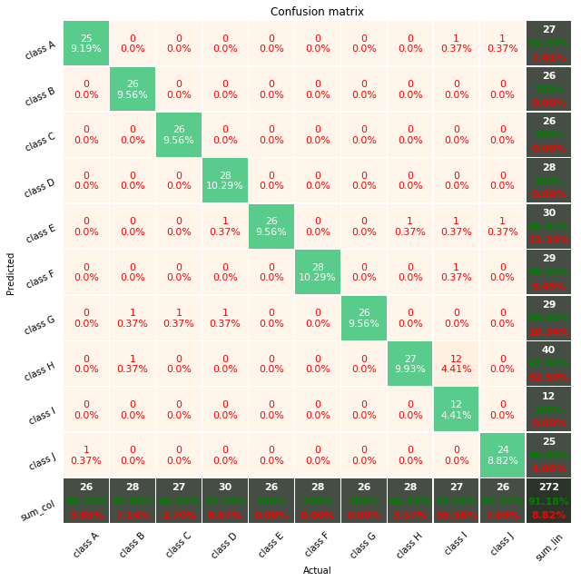

```python
confusion_matrix_pretty_print.plot_confusion_matrix_from_data(test_gen_resnet50.classes, test_prediction_classes_resnet)
```

#### Training / Testing accurecy loss graph

you can view graphs below ...

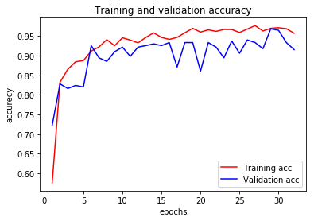

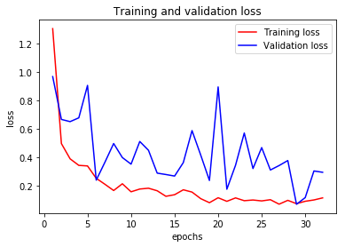

```python
acc_res = model_resnet_history.history['acc']
val_acc_res = model_resnet_history.history['val_acc']
loss_res = model_resnet_history.history['loss']
val_loss_res = model_resnet_history.history['val_loss']
epochs = range(1, len(acc) + 1)

import matplotlib.pyplot as plt

plt.title('Training and validation accuracy')
plt.plot(epochs, acc_res, 'red', label='Training acc')
plt.plot(epochs, val_acc_res, 'blue', label='Validation acc')
plt.xlabel("epochs")
plt.ylabel("accurecy")
plt.legend()

plt.figure()
plt.title('Training and validation loss')
plt.plot(epochs, loss_res, 'red', label='Training loss')
plt.plot(epochs, val_loss_res, 'blue', label='Validation loss')
plt.xlabel("epochs")
plt.ylabel("loss")

plt.legend()

plt.show()
```

### Reflection

This is quite intersting problem. This is an example of multi-class classification probelm. so to be precise these are the steps involved

preprocess the data: So the data we have got is having folder with 10 subfolders in it.. this means 10 diffrent classes of data. so we need to use kereas flow_from_dir imagegenrator technique . which will create the sample images genrated from it..this will help us to solve the data imbalance issues.

use algorithm to train the data: well choosing best algorithm is diffcult task always.. this depends upon 2 things how much mem/cpu you have to train those milloins of paramters how much accurecy you need

```
 i have taken resnet beacuse  training resnet are easy as they  backpropagate errors fastly and train fastly
```

once i got good results from resnet i used it as a part of my solution

Diffcult part of solution was the : data preprocessing .. this is toughest task as we need to deal with data imabalence and make sure we have correct data set

The final model was good as per my expectations if we look at confusion matrix and accurecy/loss grpah.. we can clearly see that model is repsonding well for unseen data .. this means the model is genarlizing well

# Improvement

We need to try this with other cnn models like Xception and others .. Also the number of epochs i used are very less. we can use even more to get better results.

The algrotihm that i think might have done better was xception algorithm .. probably i should try that algorithm also

SO there can be better chance to get even more accurecy .. if we try with

```
diffrent CNN models  (espicailly xcpetion)
diffrent Gradient decent  optimization algorithms
```

yes there could be even better solution exists .. using xception

# References

We have created a model which will predict the species of monkey if image is given. we can use it for any other application

some of the ideas i have used are from diffrent kernels in kagggle

Also i used pretty_print_confusion_matrix from github https://github.com/wcipriano/pretty-print-confusion-matrix/blob/master/confusion_matrix_pretty_print.py